# DV_FinalProject

Madeline Packard and Arthur DeVitalis

May 13, 2015

For our final project, we wanted to explore data provided by the government of Canada through their Open Data portal. We choose this source for its credibility, accessibility, and variety of comparative datasets.

## The Data: College Graduates Survey

As college students ourselves, we were interested in looking into Canadian college graduate data. We’re familiar with US graduation and employment rates, so we tried a neighboring country.

```r
source("../02 Data Wrangling/Dataframes.R", echo = FALSE)
```

#### Grad Earnings, by Gender and Median Earning

```r
grad_earnings <- data.frame(fromJSON(getURL(URLencode(gsub("\n", " ", '129.152.144.84:5001/rest/native/?query= "select REF_DATE, GEO, SCHOOL, GENDER, STATS, VALUE from GRAD_EARNINGS "')),httpheader=c(DB='jdbc:oracle:thin:@129.152.144.84:1521:ORCL', USER='C##cs329e_map4542', PASS='orcl_map4542', MODE='native_mode', MODEL='model', returnDimensions = 'False', returnFor = 'JSON'), verbose = TRUE)))
```

```
## Source: local data frame [1,080 x 6]
##
##    REF_DATE                  GEO  SCHOOL     GENDER           STATS VALUE
## 1      2000 Prince Edward Island Masters Both sexes          Median  null
## 2      2005 Prince Edward Island Masters Both sexes          Median 65000
## 3      2010 Prince Edward Island Masters Both sexes          Median 78000
## 4      2000 Prince Edward Island Masters Both sexes 75th percentile  null
## 5      2005 Prince Edward Island Masters Both sexes 75th percentile  null
## 6      2010 Prince Edward Island Masters Both sexes 75th percentile  null
## 7      2000 Prince Edward Island Masters      Males 25th percentile  null
## 8      2005 Prince Edward Island Masters      Males 25th percentile  null
## 9      2010 Prince Edward Island Masters      Males 25th percentile  null
## 10     2000 Prince Edward Island Masters      Males          Median  null
## ..      ...                  ...     ...        ...             ...   ...
```

Using data wrangling, we can compare the average salary for doctorate graduates with the average salary for college graduates, by gender.

##### Average Doctorate Earnings

For our graduate earnings data, we looked at the pay gap between men and women’s average salary, at different schooling levels.

```r
doctorate_earnings <- grad_earnings %>% filter(SCHOOL %in% c("Doctorate"), STATS == "Median", GENDER != "Both sexes", VALUE != "null")
```

```
## Source: local data frame [45 x 6]
##
##    REF_DATE           GEO    SCHOOL  GENDER  STATS VALUE
## 1      2000   Nova Scotia Doctorate   Males Median 52000
## 2      2005   Nova Scotia Doctorate   Males Median 57200
## 3      2010   Nova Scotia Doctorate   Males Median 72000
## 4      2000   Nova Scotia Doctorate Females Median 57900
## 5      2005   Nova Scotia Doctorate Females Median 57800
## 6      2010   Nova Scotia Doctorate Females Median 76000
## 7      2010 New Brunswick Doctorate   Males Median 92000
## 8      2005 New Brunswick Doctorate Females Median 68300
## 9      2010 New Brunswick Doctorate Females Median 81000
## 10     2000        Quebec Doctorate   Males Median 60000
## ..      ...           ...       ...     ...    ...   ...
```

From this data, we created a visualization of average salary of doctorate graduates, by gender.

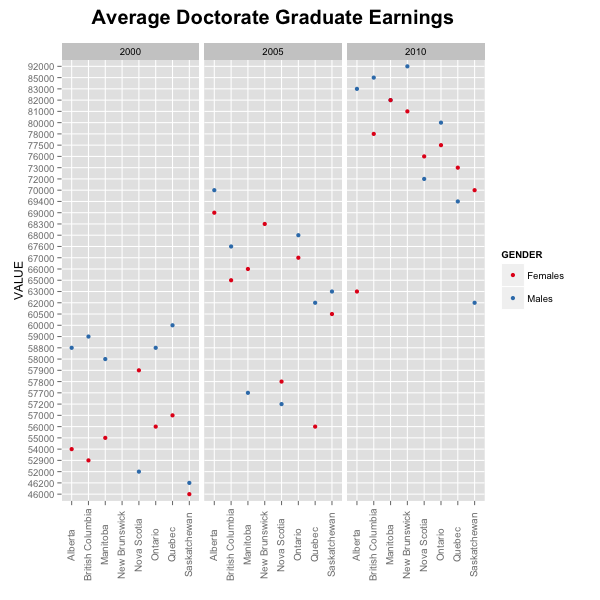

```r
doctorate_earnings %>% ggplot(aes(x=GEO, y=VALUE, color=GENDER)) + geom_point() + ggtitle('Average Doctorate Graduate Earnings') + scale_color_brewer(palette="Set1") + facet_wrap(~REF_DATE) + theme(axis.text.x=element_text(angle=90, size=10, vjust=0.4), plot.title = element_text(size=20, face="bold", vjust=2), axis.title.x = element_blank())
```

##### Average College Earnings

```r
college_earnings <- grad_earnings %>% filter(SCHOOL %in% c("College"), STATS == "Median", GENDER != "Both sexes", VALUE != "null")
```

```
## Source: local data frame [60 x 6]
##
##    REF_DATE           GEO  SCHOOL  GENDER  STATS VALUE
## 1      2000   Nova Scotia College   Males Median 29100
## 2      2005   Nova Scotia College   Males Median 32800
## 3      2010   Nova Scotia College   Males Median 41600
## 4      2000   Nova Scotia College Females Median 21200
## 5      2005   Nova Scotia College Females Median 27200
## 6      2010   Nova Scotia College Females Median 34000
## 7      2000 New Brunswick College   Males Median 29400
## 8      2005 New Brunswick College   Males Median 33300
## 9      2010 New Brunswick College   Males Median 38000
## 10     2000 New Brunswick College Females Median 25000
## ..      ...           ...     ...     ...    ...   ...
```

Here, we did a similiar wrangle to the average salary of college graduates, by gender.

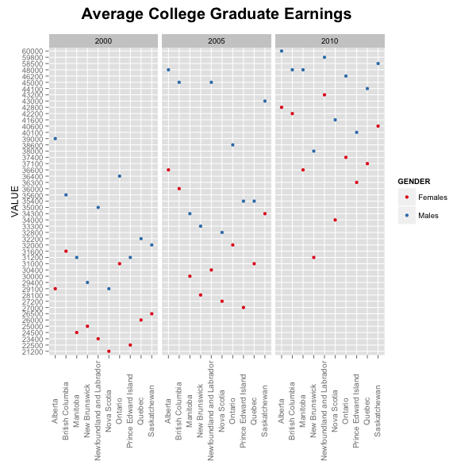

```r
college_earnings %>% ggplot(aes(x=GEO, y=VALUE, color=GENDER)) + geom_point() + ggtitle('Average College Graduate Earnings') + scale_color_brewer(palette="Set1") + facet_wrap(~REF_DATE) + theme(axis.text.x=element_text(angle=90, size=10, vjust=0.4), plot.title = element_text(size=20, face="bold", vjust=2), axis.title.x = element_blank())
```

#### Grad Debt, by Averages and Percentages of Grads who have Paid Off

```r
grad_debt <- data.frame(fromJSON(getURL(URLencode(gsub("\n", " ", '129.152.144.84:5001/rest/native/?query= "select REF_DATE, GEO, SCHOOL, SOURCE, STATS, VALUE from GRAD_DEBT "')),httpheader=c(DB='jdbc:oracle:thin:@129.152.144.84:1521:ORCL', USER='C##cs329e_map4542', PASS='orcl_map4542', MODE='native_mode', MODEL='model', returnDimensions = 'False', returnFor = 'JSON'), verbose = TRUE)))
```

```
## Source: local data frame [1,800 x 6]
##
##    REF_DATE                       GEO    SCHOOL
## 1      2000 Newfoundland and Labrador Bachelors
## 2      2005 Newfoundland and Labrador Bachelors
## 3      2010 Newfoundland and Labrador Bachelors
## 4      2000 Newfoundland and Labrador Bachelors
## 5      2005 Newfoundland and Labrador Bachelors
## 6      2010 Newfoundland and Labrador Bachelors
## 7      2000 Newfoundland and Labrador Bachelors
## 8      2005 Newfoundland and Labrador Bachelors
## 9      2010 Newfoundland and Labrador Bachelors
## 10     2000 Newfoundland and Labrador Bachelors
## ..      ...                       ...       ...
## Variables not shown: SOURCE (fctr), STATS (fctr), VALUE (fctr)
```

From this data, we wanted to create a visualization for the average debt owed for students to government loan programs, for the year 2010.

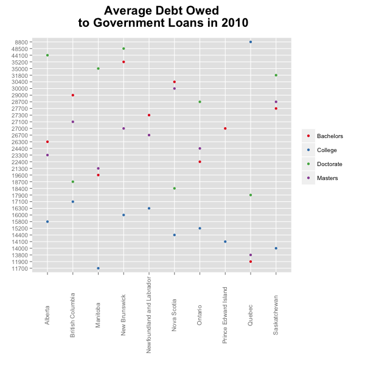

```r
debt2010 <- grad_debt %>% filter(REF_DATE == 2010, SOURCE == "Graduates who owed money for their education to government student loan programs", STATS == "Average debt owed to the source at time of graduation dollars", VALUE != "null") %>% ggplot(aes(x=GEO, y=VALUE, color=SCHOOL)) + geom_point() + ggtitle('Average Debt Owed\n to Government Loans in 2010') + scale_color_brewer(palette="Set1") + theme(axis.text.x=element_text(angle=90, size=10, vjust=0.4), axis.title.y = element_blank(), axis.title.x = element_blank(), legend.title=element_blank(), plot.title = element_text(size=20, face="bold", vjust=2, lineheight=0.8))
```

#### Grad Employment, by Rates and Percentages

```r
grad_employment <- data.frame(fromJSON(getURL(URLencode(gsub("\n", " ", '129.152.144.84:5001/rest/native/?query= "select REF_DATE, GEO, SCHOOL, GENDER, STATS, VALUE from GRAD_EMPLOYMENT "')),httpheader=c(DB='jdbc:oracle:thin:@129.152.144.84:1521:ORCL', USER='C##cs329e_map4542', PASS='orcl_map4542', MODE='native_mode', MODEL='model', returnDimensions = 'False', returnFor = 'JSON'), verbose = TRUE)))
```

```
## Source: local data frame [2,160 x 6]
##
##    REF_DATE                       GEO  SCHOOL     GENDER
## 1      2005 Newfoundland and Labrador Masters Both sexes
## 2      2010 Newfoundland and Labrador Masters Both sexes
## 3      2000 Newfoundland and Labrador Masters      Males
## 4      2005 Newfoundland and Labrador Masters      Males
## 5      2010 Newfoundland and Labrador Masters      Males
## 6      2000 Newfoundland and Labrador Masters      Males
## 7      2005 Newfoundland and Labrador Masters      Males
## 8      2010 Newfoundland and Labrador Masters      Males
## 9      2000 Newfoundland and Labrador Masters      Males
## 10     2005 Newfoundland and Labrador Masters      Males
## ..      ...                       ...     ...        ...
## Variables not shown: STATS (fctr), VALUE (fctr)
```

We were intersted in the unemployment and emploment rates for both sexes, at the highest and lowest school levels.

##### Average College Employment Rates

```r
college_employment_rates <- grad_employment %>% filter(SCHOOL %in% c("College"), STATS %in%  c("Unemployed rate", "Employed percent"), GENDER != "Both sexes", VALUE != "null") %>% arrange(desc(VALUE))
```

```
## Source: local data frame [110 x 6]
##
##    REF_DATE                  GEO  SCHOOL  GENDER            STATS VALUE
## 1      2010              Alberta College   Males Employed percent    98
## 2      2005             Manitoba College   Males Employed percent    97
## 3      2005              Alberta College   Males Employed percent    95
## 4      2010             Manitoba College   Males Employed percent    94
## 5      2005         Saskatchewan College   Males Employed percent    94
## 6      2010     British Columbia College   Males Employed percent    94
## 7      2005     British Columbia College Females Employed percent    94
## 8      2000 Prince Edward Island College   Males Employed percent    93
## 9      2000             Manitoba College   Males Employed percent    93
## 10     2010               Quebec College   Males Employed percent    92
## ..      ...                  ...     ...     ...              ...   ...
```

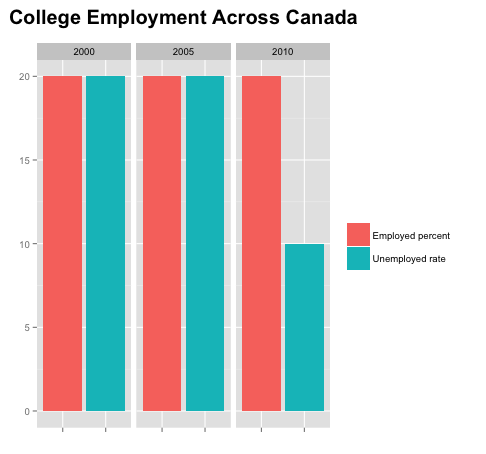

##### Average Doctorate Employment Rates

```r
doctorate_employment_rates <- grad_employment %>% filter(SCHOOL %in% c("Doctorate"), STATS %in%  c("Unemployed rate", "Employed percent"), GENDER != "Both sexes", VALUE != "null") %>% arrange(desc(VALUE)) %>% tbl_df
```

```
## Source: local data frame [69 x 6]
##
##    REF_DATE              GEO    SCHOOL  GENDER            STATS VALUE
## 1      2000         Manitoba Doctorate Females Employed percent    97
## 2      2000          Alberta Doctorate   Males Employed percent    97
## 3      2000 British Columbia Doctorate   Males Employed percent    97
## 4      2010          Alberta Doctorate Females Employed percent    96
## 5      2010           Quebec Doctorate Females Employed percent    95
## 6      2010      Nova Scotia Doctorate   Males Employed percent    95
## 7      2005         Manitoba Doctorate   Males Employed percent    95
## 8      2010         Manitoba Doctorate   Males Employed percent    95
## 9      2005          Alberta Doctorate   Males Employed percent    95
## 10     2010 British Columbia Doctorate   Males Employed percent    95
## ..      ...              ...       ...     ...              ...   ...
```

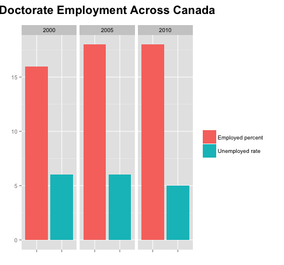

## Tableau

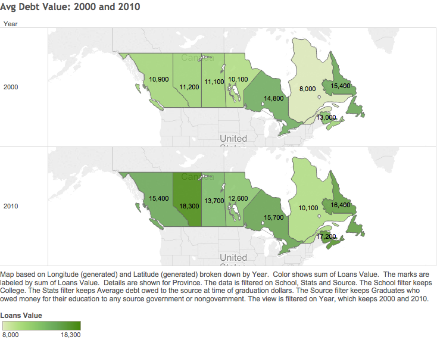

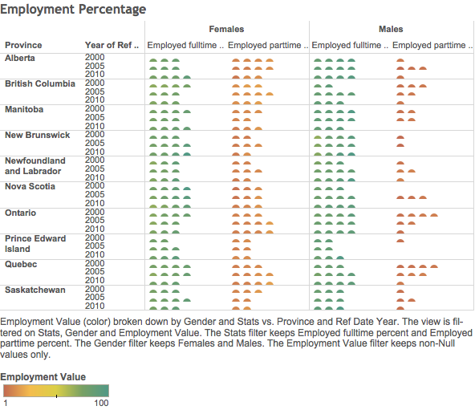

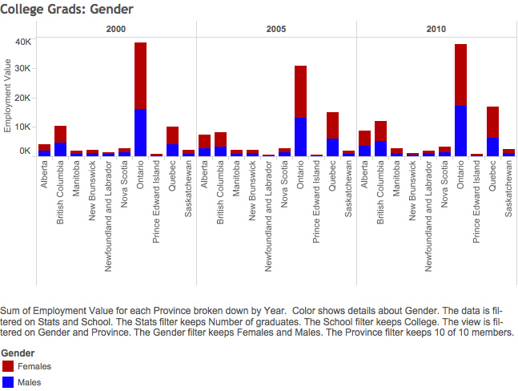

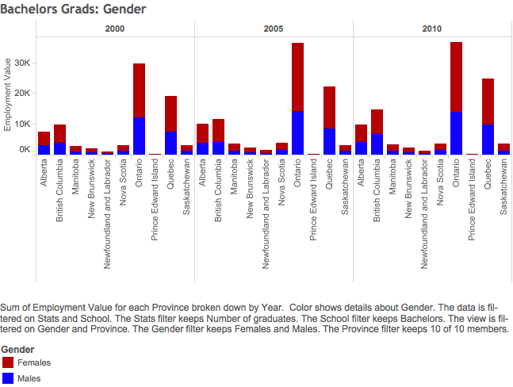

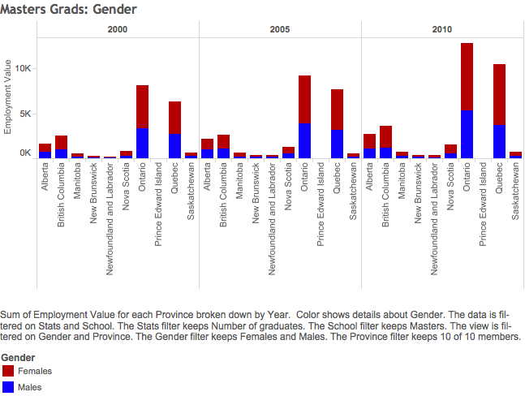

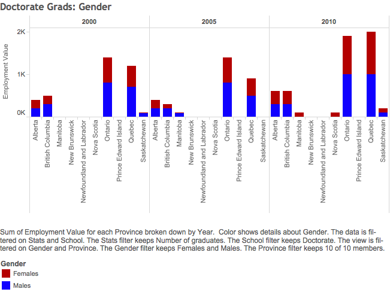

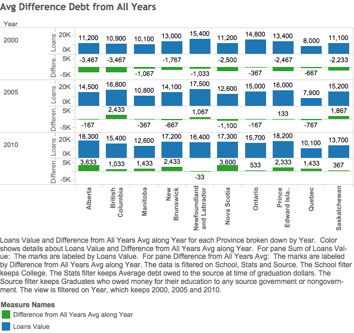

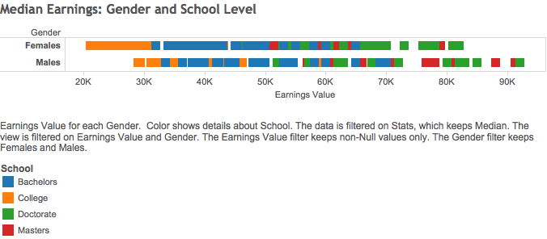